# Assignment 1

DATA311 - Machine Learning

Author

Rin Meng, 51940633

## Exploratory / Pre-processing

### Exercise 1

b. Regression

c. Supervised

### Exercise 2

```r
abalone <- read.table(("abalone.data"), header = FALSE, sep = ",")
colnames(abalone) <- c("Sex", "Length", "Diameter", "Height", "Whole_Weight", "Shucked_Weight", "Viscera_Weight", "Shell_Weight", "Rings")

str(abalone)
```

```
'data.frame':   4177 obs. of  9 variables:
 $ Sex           : chr  "M" "M" "F" "M" ...
 $ Length        : num  0.455 0.35 0.53 0.44 0.33 0.425 0.53 0.545 0.475 0.55 ...
 $ Diameter      : num  0.365 0.265 0.42 0.365 0.255 0.3 0.415 0.425 0.37 0.44 ...
 $ Height        : num  0.095 0.09 0.135 0.125 0.08 0.095 0.15 0.125 0.125 0.15 ...
 $ Whole_Weight  : num  0.514 0.226 0.677 0.516 0.205 ...
 $ Shucked_Weight: num  0.2245 0.0995 0.2565 0.2155 0.0895 ...
 $ Viscera_Weight: num  0.101 0.0485 0.1415 0.114 0.0395 ...
 $ Shell_Weight  : num  0.15 0.07 0.21 0.155 0.055 0.12 0.33 0.26 0.165 0.32 ...
 $ Rings         : int  15 7 9 10 7 8 20 16 9 19 ...
```

### Exercise 3

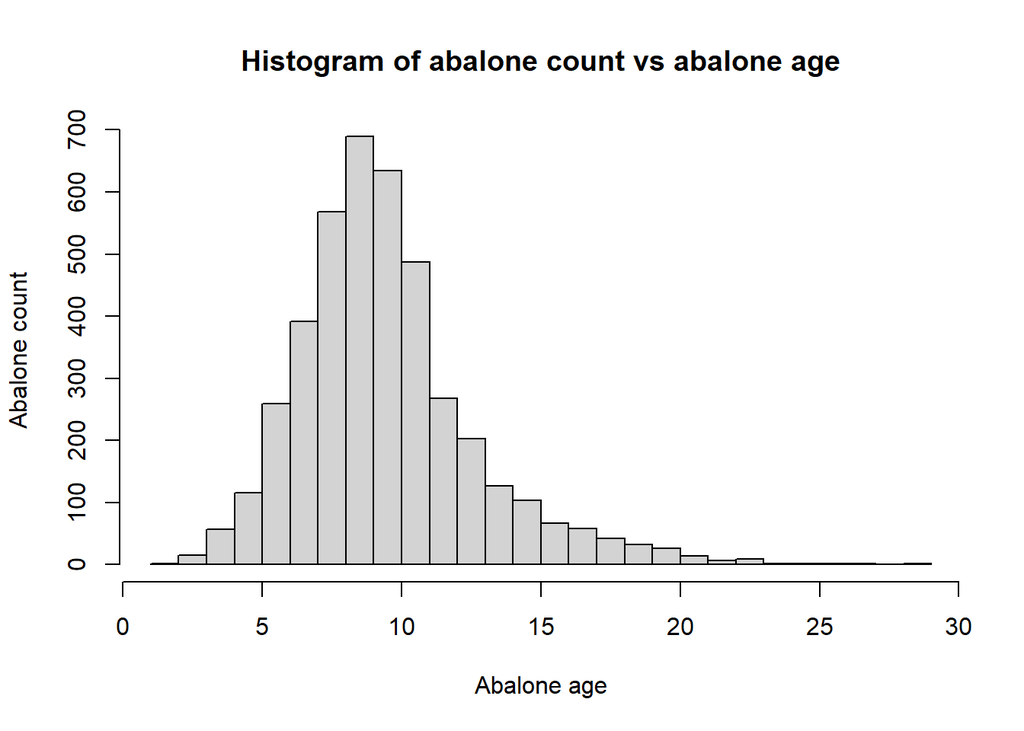

```r
hist(abalone$Rings, xlab = "Abalone age",breaks=30 , ylab = "Abalone count", main = "Histogram of abalone count vs abalone age")
```

We see that this is an observation of a skewed normally distributed histogram. This should not break any assumptions of the linear model because in a linear model, we should have a data that follows **Linearity, Independence, Homoscedasticity, Normality** and from this observation alone, we do not have enough factors to point out if it breaks any of the assumptions, there may be a few outliers that made the graph be skewed.

### Exercise 4

```r
set.seed(51940633)

# count half of the rows
sampleSize <- floor(0.5 * nrow(abalone))

# split rows into 2 sets
set <- sample(seq_len(nrow(abalone)), size = sampleSize)

abaloneTrain <- abalone[set, ]

abaloneTest <- abalone[-set, ]

abaloneTrain
```

|  | Sex | Length | Diameter | Height | Whole_Weight | Shucked_Weight | Viscera_Weight | Shell_Weight | Rings |
| --- | --- | --- | --- | --- | --- | --- | --- | --- | --- |
| 3826 | M | 0.625 | 0.470 | 0.170 | 1.1665 | 0.4605 | 0.2565 | 0.3945 | 11 |
| 3894 | I | 0.435 | 0.355 | 0.125 | 0.4075 | 0.1535 | 0.0740 | 0.1650 | 9 |
| 1027 | M | 0.645 | 0.520 | 0.175 | 1.5610 | 0.7090 | 0.3555 | 0.4000 | 8 |
| 562 | I | 0.515 | 0.400 | 0.120 | 0.6590 | 0.2705 | 0.1790 | 0.1700 | 13 |
| 800 | F | 0.425 | 0.345 | 0.110 | 0.3665 | 0.1250 | 0.0810 | 0.1170 | 11 |
| 567 | I | 0.485 | 0.355 | 0.130 | 0.5810 | 0.2450 | 0.1320 | 0.1680 | 12 |
| 119 | F | 0.560 | 0.430 | 0.150 | 0.8825 | 0.3465 | 0.1720 | 0.3100 | 9 |
| 3017 | I | 0.435 | 0.335 | 0.105 | 0.3535 | 0.1560 | 0.0500 | 0.1135 | 7 |
| 3655 | I | 0.530 | 0.420 | 0.140 | 0.6765 | 0.2560 | 0.1855 | 0.2080 | 9 |
| 853 | M | 0.565 | 0.450 | 0.155 | 1.0595 | 0.4735 | 0.2400 | 0.2650 | 10 |

[output cut: 2078 more lines]

```r
abaloneTest
```

|  | Sex | Length | Diameter | Height | Whole_Weight | Shucked_Weight | Viscera_Weight | Shell_Weight | Rings |
| --- | --- | --- | --- | --- | --- | --- | --- | --- | --- |
| 1 | M | 0.455 | 0.365 | 0.095 | 0.5140 | 0.2245 | 0.1010 | 0.1500 | 15 |
| 2 | M | 0.350 | 0.265 | 0.090 | 0.2255 | 0.0995 | 0.0485 | 0.0700 | 7 |
| 3 | F | 0.530 | 0.420 | 0.135 | 0.6770 | 0.2565 | 0.1415 | 0.2100 | 9 |
| 5 | I | 0.330 | 0.255 | 0.080 | 0.2050 | 0.0895 | 0.0395 | 0.0550 | 7 |
| 8 | F | 0.545 | 0.425 | 0.125 | 0.7680 | 0.2940 | 0.1495 | 0.2600 | 16 |
| 10 | F | 0.550 | 0.440 | 0.150 | 0.8945 | 0.3145 | 0.1510 | 0.3200 | 19 |
| 11 | F | 0.525 | 0.380 | 0.140 | 0.6065 | 0.1940 | 0.1475 | 0.2100 | 14 |
| 13 | M | 0.490 | 0.380 | 0.135 | 0.5415 | 0.2175 | 0.0950 | 0.1900 | 11 |
| 14 | F | 0.535 | 0.405 | 0.145 | 0.6845 | 0.2725 | 0.1710 | 0.2050 | 10 |
| 15 | F | 0.470 | 0.355 | 0.100 | 0.4755 | 0.1675 | 0.0805 | 0.1850 | 10 |

[output cut: 2079 more lines]

## Simple Linear Regression

### Exercise 5

```r
abaloneTrain.lm <- lm(Rings ~ Length, data=abaloneTrain)
summary(abaloneTrain.lm)
```

```
Call:
lm(formula = Rings ~ Length, data = abaloneTrain)

Residuals:
    Min      1Q  Median      3Q     Max
-4.9666 -1.6867 -0.7383  0.8894 14.9614

Coefficients:
            Estimate Std. Error t value Pr(>|t|)
(Intercept)   2.3975     0.2667   8.988   <2e-16 ***
Length       14.4019     0.4971  28.972   <2e-16 ***
---
Signif. codes:  0 '***' 0.001 '**' 0.01 '*' 0.05 '.' 0.1 ' ' 1

Residual standard error: 2.677 on 2086 degrees of freedom
Multiple R-squared:  0.2869,    Adjusted R-squared:  0.2866
F-statistic: 839.4 on 1 and 2086 DF,  p-value: < 2.2e-16
```

Since the p value for the **length** coefficient is incredibly small at $2 \times 10^{-16}$, we can safely say that there is a significant relationship between abalone’s **length** and **rings**.

### Exercise 7

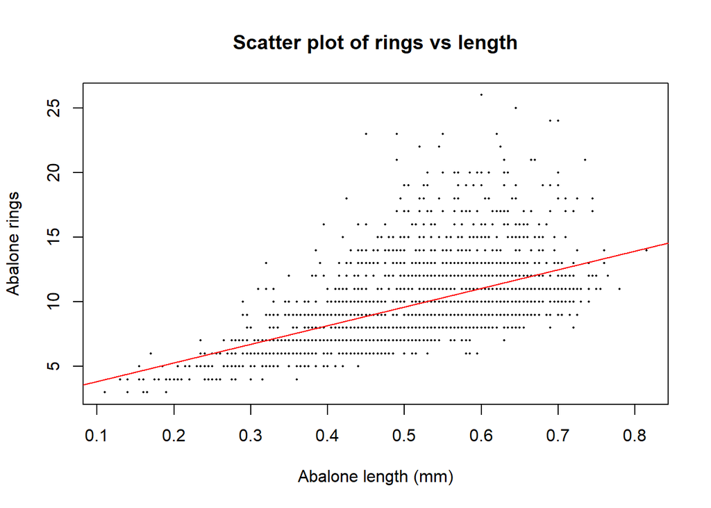

```r
plot(abaloneTrain$Length, abaloneTrain$Rings, xlab="Abalone length (mm)", ylab="Abalone rings",
     pch=16,cex=0.3, main = "Scatter plot of rings vs length")
abline(abaloneTrain.lm, col = "red")
```

### Exercise 8

The **scatter plot** of **Rings vs Length** indicates that there is an underlying pattern, therefore it implies that this model violated:

1. **Homoscedasticity:** There is no visible constant variance between each dots, therefore, this model is heteroscedasticity.
2. **Linearity:** Since there is a pattern, therefore, linearity is also violated.

### Exercise 9

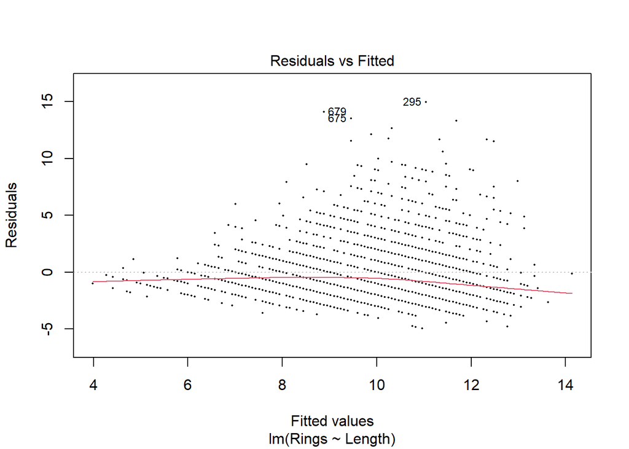

```r
plot(abaloneTrain.lm, which = 1, pch=16, cex=0.3)
```

**Residuals vs fitted** plot shows that there are patterns in the plot, which suggests that the relationship between the predictor and response variable is not purely linear and this suggests that the model is giving a biased estimate.

## **Multiple Linear Regression**

### Exercise 10

```r
abaloneTrain.lm2 <- lm(Rings ~ Length + I(Length^2), data=abaloneTrain)
summary(abaloneTrain.lm2)
```

```
Call:
lm(formula = Rings ~ Length + I(Length^2), data = abaloneTrain)

Residuals:
    Min      1Q  Median      3Q     Max
-5.0260 -1.7427 -0.7002  0.8966 14.9198

Coefficients:
            Estimate Std. Error t value Pr(>|t|)
(Intercept)  -1.2151     0.7688  -1.581    0.114
Length       30.2225     3.1984   9.449  < 2e-16 ***
I(Length^2) -16.2173     3.2392  -5.006 6.01e-07 ***
---
Signif. codes:  0 '***' 0.001 '**' 0.01 '*' 0.05 '.' 0.1 ' ' 1

Residual standard error: 2.661 on 2085 degrees of freedom
Multiple R-squared:  0.2954,    Adjusted R-squared:  0.2947
F-statistic: 437.1 on 2 and 2085 DF,  p-value: < 2.2e-16
```

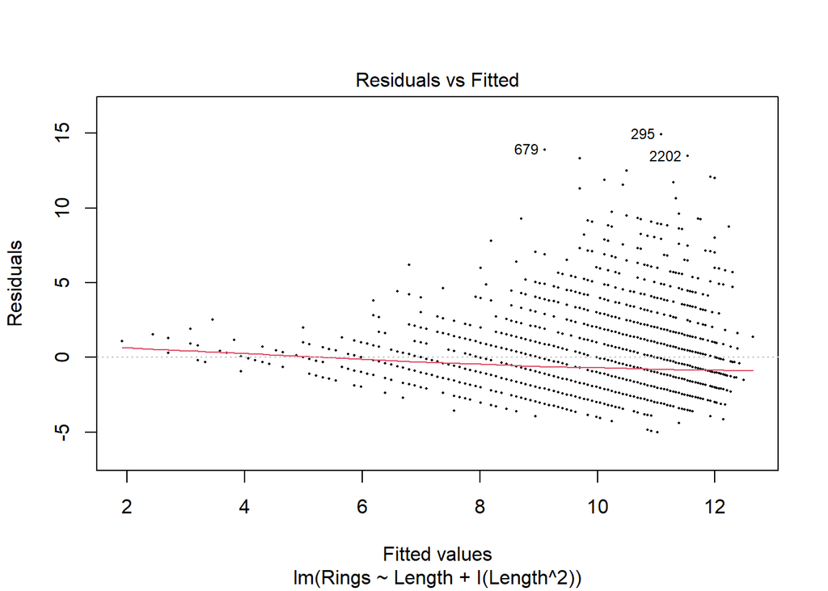

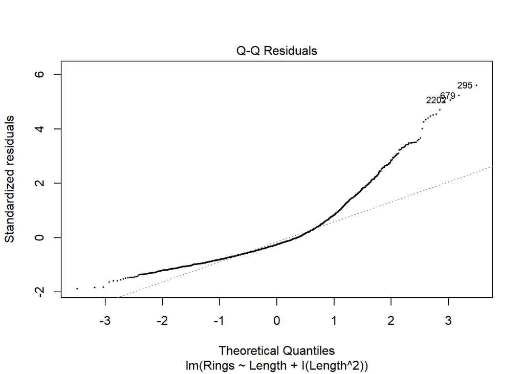

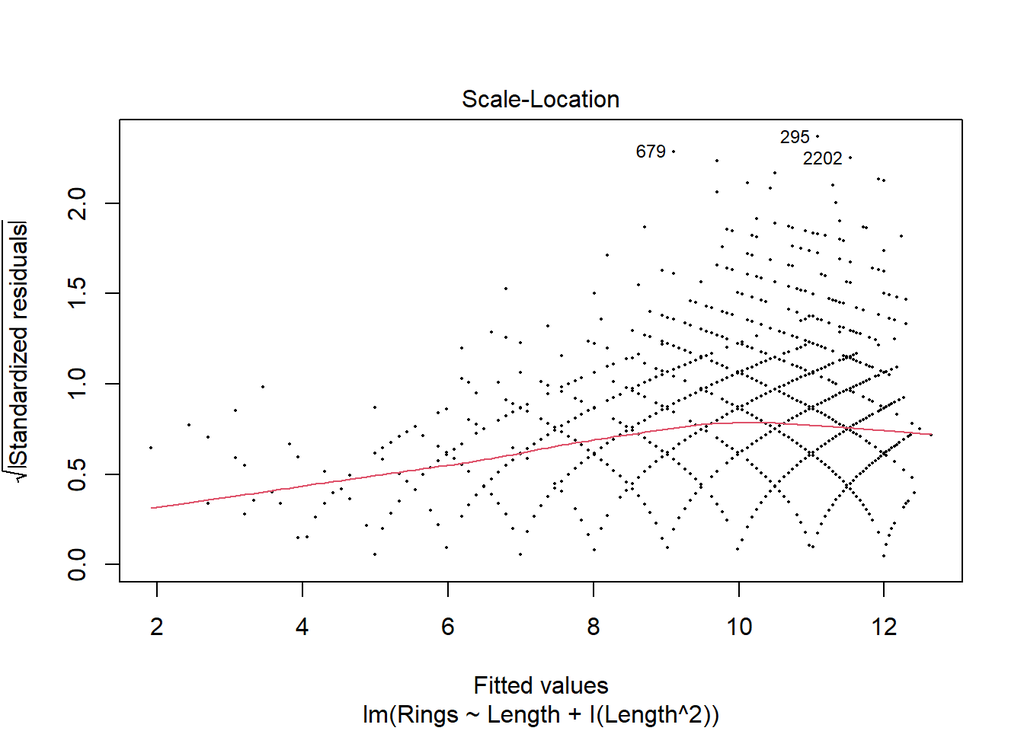

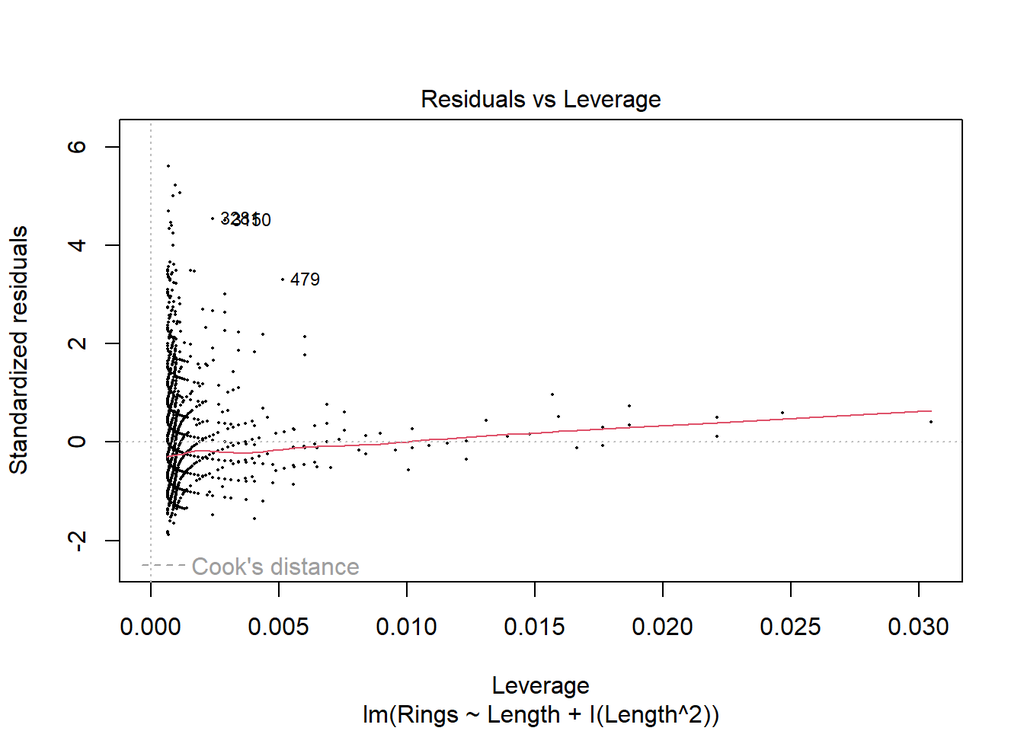

```r
plot(abaloneTrain.lm2, pch=16, cex=0.3)
```

### Exercise 11

```r
abaloneTrain.lm3 <- lm(Rings ~ Length + Sex, data=abaloneTrain)
summary(abaloneTrain.lm3)
```

```
Call:
lm(formula = Rings ~ Length + Sex, data = abaloneTrain)

Residuals:
    Min      1Q  Median      3Q     Max
-5.2702 -1.6776 -0.6199  0.8036 14.8036

Coefficients:
            Estimate Std. Error t value Pr(>|t|)
(Intercept)   4.4106     0.3448  12.791   <2e-16 ***
Length       11.5287     0.5741  20.081   <2e-16 ***
SexI         -1.4391     0.1661  -8.665   <2e-16 ***
SexM         -0.1314     0.1401  -0.938    0.348
---
Signif. codes:  0 '***' 0.001 '**' 0.01 '*' 0.05 '.' 0.1 ' ' 1

Residual standard error: 2.622 on 2084 degrees of freedom
Multiple R-squared:  0.3162,    Adjusted R-squared:  0.3152
F-statistic: 321.3 on 3 and 2084 DF,  p-value: < 2.2e-16
```

By adding the `Sex` as a categorical predictor in the regression model, we can clearly that:

- Sex = I is highly significant with a p-value of $2 \times 10^{-16}$.
- Sex = M is insignificant with a p-value of $0.348$.
- **Model with only Length:** Adjusted R-squared = $0.2866$
- **Model with Length + Sex:** Adjusted R-squared = $0.3152$

The adjusted R-squared value increased from $0.2866$ to $0.3152$, indicating that adding `Sex` as a predictor improves the model fit by explaining more variance in the response variable.

Therefore, we can conclude that, adding the `Sex` as a categorical predictor variable significantly improves the model.

### Exercise 12

$$\begin{equation}
Rings =
\begin{cases}
\hat{Y} = 4.4106 + 11.5287 \cdot Length & \text{if Female} \\
\hat{Y} = 4.4106 + 11.5287 \cdot Length - 0.1314 & \text{if Male} \\
\hat{Y} = 4.4106 + 11.5287 \cdot Length - 1.4391 & \text{if Infant}
\end{cases}
\end{equation}$$

### Exercise 13

The reference level for the model fitted in Exercise 11 is **Female** because the coefficients for both, `Sex = "M"` and `Sex = "I"` are provided, therefore, their values are interpreted with relative to the reference category, `Sex = "F"`.

### Exercise 14

Based on this data, and the predicted $\hat{Y}$ shown above, it seems to be that the **female** abalone tend to have the oldest average age, then **male**, then **infant**.

### Exercise 15

```r
abaloneTrain.lm3withWholeWeight <- lm(Rings ~ Length + Sex + Whole_Weight, data=abaloneTrain)

abaloneTrain.forward <- step(abaloneTrain.lm3, scope = list(lower = abaloneTrain.lm3, upper = abaloneTrain.lm3withWholeWeight), direction = "forward")
```

```
Start:  AIC=4030.11
Rings ~ Length + Sex

               Df Sum of Sq   RSS    AIC
+ Whole_Weight  1    26.368 14306 4028.3
<none>                      14332 4030.1

Step:  AIC=4028.26
Rings ~ Length + Sex + Whole_Weight
```

```r
summary(abaloneTrain.forward)
```

```
Call:
lm(formula = Rings ~ Length + Sex + Whole_Weight, data = abaloneTrain)

Residuals:
    Min      1Q  Median      3Q     Max
-5.2972 -1.6753 -0.6217  0.8396 14.8494

Coefficients:
             Estimate Std. Error t value Pr(>|t|)
(Intercept)    5.0823     0.4861  10.456  < 2e-16 ***
Length         9.2415     1.3006   7.105 1.64e-12 ***
SexI          -1.3982     0.1673  -8.359  < 2e-16 ***
SexM          -0.1407     0.1401  -1.004   0.3153
Whole_Weight   0.6279     0.3205   1.959   0.0502 .
---
Signif. codes:  0 '***' 0.001 '**' 0.01 '*' 0.05 '.' 0.1 ' ' 1

Residual standard error: 2.621 on 2083 degrees of freedom
Multiple R-squared:  0.3175,    Adjusted R-squared:  0.3162
F-statistic: 242.2 on 4 and 2083 DF,  p-value: < 2.2e-16
```

## **Multiple Linear Regression**

### Exercise 16

```r
numeric_columns <- sapply(abalone, is.numeric)

corTable <- cor(abalone[, numeric_columns])
diag(corTable) <- NA

maxCor <- max(corTable, na.rm = TRUE)

maxCorIndex <- which(corTable == maxCor, arr.ind = TRUE)

corTable
```

```
                  Length  Diameter    Height Whole_Weight Shucked_Weight
Length                NA 0.9868116 0.8275536    0.9252612      0.8979137
Diameter       0.9868116        NA 0.8336837    0.9254521      0.8931625
Height         0.8275536 0.8336837        NA    0.8192208      0.7749723
Whole_Weight   0.9252612 0.9254521 0.8192208           NA      0.9694055
Shucked_Weight 0.8979137 0.8931625 0.7749723    0.9694055             NA
Viscera_Weight 0.9030177 0.8997244 0.7983193    0.9663751      0.9319613
Shell_Weight   0.8977056 0.9053298 0.8173380    0.9553554      0.8826171
Rings          0.5567196 0.5746599 0.5574673    0.5403897      0.4208837
               Viscera_Weight Shell_Weight     Rings
Length              0.9030177    0.8977056 0.5567196
Diameter            0.8997244    0.9053298 0.5746599
Height              0.7983193    0.8173380 0.5574673
Whole_Weight        0.9663751    0.9553554 0.5403897
Shucked_Weight      0.9319613    0.8826171 0.4208837
Viscera_Weight             NA    0.9076563 0.5038192
Shell_Weight        0.9076563           NA 0.6275740
Rings               0.5038192    0.6275740        NA
```

```r
maxCor
```

```
[1] 0.9868116
```

```r
maxCorIndex
```

```
         row col
Diameter   2   1
Length     1   2
```

Ignoring correlation between the predictor and itself, the highest correlation we have is the two variables, `Diameter` and `Length` which is the variable **Length** and **Diameter**, both being highly correlated to each other out of the other pairs.

Implications of this **multicollinearity** is:

- **Unstable coefficient estimates**: the coefficients of the correlated predictors can become very sensitive to small changes in the model that we have. Small changes can lead to very skewed outcome.
- **Inflated standard errors**: high correlation between predictors can inflate standard errors of coefficient estimates.
- **Reduction of overall interpretability**: it will be difficult to determine the effect of each predictor in the response variable. High correlation means it is providing redundant information.

### Exercise 17

```r
abaloneTrain.lm4 <- lm(Rings ~ Length + Whole_Weight, data=abaloneTrain)
summary(abaloneTrain.lm4)
```

```
Call:
lm(formula = Rings ~ Length + Whole_Weight, data = abaloneTrain)

Residuals:
    Min      1Q  Median      3Q     Max
-5.0178 -1.7037 -0.7474  0.9433 15.0202

Coefficients:
             Estimate Std. Error t value Pr(>|t|)
(Intercept)    3.6531     0.4597   7.946 3.12e-15 ***
Length        10.3099     1.3186   7.819 8.39e-15 ***
Whole_Weight   1.0788     0.3221   3.349 0.000825 ***
---
Signif. codes:  0 '***' 0.001 '**' 0.01 '*' 0.05 '.' 0.1 ' ' 1

Residual standard error: 2.67 on 2085 degrees of freedom
Multiple R-squared:  0.2907,    Adjusted R-squared:  0.2901
F-statistic: 427.3 on 2 and 2085 DF,  p-value: < 2.2e-16
```

Comparing the **R-squared** and **Adjusted R-squared** values for this model with **Exercise 5**, we see that in **Exercise 5**, we have a linear model of **Rings** as a response variable and **Length** as the predictor variable:

- **Multiple R-squared**: $0.2869$
- **Adjusted R-squared**: $0.2866$

Here, when we have a linear model of **Rings** as a response variable and **Length** and **Whole Weight** as the predictor variable:

- **Multiple R-squared**: $0.2907$
- **Adjusted R-squared**: $0.2901$

What do these values tell us: The **Multiple R-squared** value increased from $0.2869$ to $0.2907$. This indicates that the addition of **Whole Weight** as a predictor has just slightly improved the model. The **Adjusted R-squared** value also increased from $0.2866$ to $0.2901$. This suggests that the improvement in the model’s performance just because we added new predictors, but the **Whole Weight** variable actually contributes information to our model.

Why the difference: **Multiple R-squared** will always be increased when there are new predictor variable introduced even if the new predictors doesn’t improve the model, and that is why **Adjusted R-squared** will provide a more accurate measurement of the model performance by taking away the contribution of unnecessary predictors.

### Exercise 18

```r
interactionModel <- lm(Rings ~ Length * Whole_Weight, data = abaloneTrain)
summary(interactionModel)
```

```
Call:
lm(formula = Rings ~ Length * Whole_Weight, data = abaloneTrain)

Residuals:
    Min      1Q  Median      3Q     Max
-5.5605 -1.6860 -0.6331  0.9682 14.8477

Coefficients:
                    Estimate Std. Error t value Pr(>|t|)
(Intercept)           3.7024     0.4479   8.266 2.43e-16 ***
Length                5.0588     1.3763   3.676 0.000243 ***
Whole_Weight         13.3191     1.1938  11.157  < 2e-16 ***
Length:Whole_Weight -15.2407     1.4342 -10.627  < 2e-16 ***
---
Signif. codes:  0 '***' 0.001 '**' 0.01 '*' 0.05 '.' 0.1 ' ' 1

Residual standard error: 2.601 on 2084 degrees of freedom
Multiple R-squared:  0.3272,    Adjusted R-squared:  0.3262
F-statistic: 337.8 on 3 and 2084 DF,  p-value: < 2.2e-16
```

The **interaction term** `Length:Whole_Weight` has a very low p-value at $2 \times 10^{-16}$, making it statistically significant. The negative coefficient of the interaction term suggests that, as the variable **Whole Weight** increases, the effect of **Length** on the number of **Rings** decreases.

### Exercise 19

```r
multipleRegression <- lm (Rings ~ ., data = abaloneTrain)
summary(multipleRegression)
```

```
Call:
lm(formula = Rings ~ ., data = abaloneTrain)

Residuals:
    Min      1Q  Median      3Q     Max
-7.6595 -1.2919 -0.3362  0.8606 11.7425

Coefficients:
                Estimate Std. Error t value Pr(>|t|)
(Intercept)      4.09606    0.41673   9.829  < 2e-16 ***
SexI            -0.97703    0.14229  -6.866 8.67e-12 ***
SexM             0.01019    0.11746   0.087   0.9309
Length           2.80658    2.62914   1.067   0.2859
Diameter         7.86180    3.21181   2.448   0.0145 *
Height           7.90140    1.78798   4.419 1.04e-05 ***
Whole_Weight     9.59487    1.04544   9.178  < 2e-16 ***
Shucked_Weight -20.89456    1.18326 -17.658  < 2e-16 ***
Viscera_Weight -11.58037    1.87339  -6.182 7.62e-10 ***
Shell_Weight     8.59817    1.64367   5.231 1.85e-07 ***
---
Signif. codes:  0 '***' 0.001 '**' 0.01 '*' 0.05 '.' 0.1 ' ' 1

Residual standard error: 2.187 on 2078 degrees of freedom
Multiple R-squared:  0.5257,    Adjusted R-squared:  0.5236
F-statistic: 255.9 on 9 and 2078 DF,  p-value: < 2.2e-16
```

The predictors that are statistically significant (p-value $< 0.05$) are:

1. **Sex = I**: p-value $= 8.67 \times 10^{-12}$
2. **Diameter**: p-value $= 0.0145$
3. **Height**: p-value $= 1.04 \times 10^{-05}$
4. **Whole_Weight**: p-value = $2 \times 10^{-16}$
5. **Shucked_Weight**: p-value $< 2 \times 10^{-16}$
6. **Viscera_Weight**: p-value $= 7.62 \times 10^{-10}$
7. **Shell_Weight**: p-value $= 1.85 \times 10^{-07}$

### Exercise 20

I would have chose:

1. **Sex = Male**: The p-value is 0.9309 which is not statistically significant, therefore it is unlikely to have impact on the model’s performance.
2. **Length**: The p-value is 0.2859, which is also not statistically significant, and also, it is highly correlated with the **Diameter**.

I would expect the model’s prediction to be better, where the **Adjusted R-squared** value is much higher of any of the observed model that we have created throughout this exercise.

### Exercise 21

```r
myModel <- lm(Rings ~ Sex * Diameter * Height * Whole_Weight *
            Shucked_Weight * Viscera_Weight * Shell_Weight, data = abaloneTrain)
summary(myModel)$adj.r.squared
```

```
[1] 0.6051785
```

## Model Comparison

### Exercise 22

| Exercise | Adjusted $R^2$ | $RSE_{train}$ | $MSE_{test}$ |
| --- | --- | --- | --- |
| 5 | 0.2865826 | 2.6767743 | 7.1938436 |
| 10 | 0.294719 | 2.6614664 | 7.1352528 |
| 11 | 0.3152479 | 2.6224461 | 6.9773608 |
| 15 | 0.3161796 | 2.6206615 | 6.950518 |
| 17 | 0.2900598 | 2.6702429 | 7.1410472 |
| 18 | 0.3262299 | 2.6013319 | 6.739233 |
| 19 | 0.5236232 | 2.1873345 | 4.8763293 |
| 21 | 0.6051785 | 1.9913164 | 6.7282685 |

### Exercise 23

For the best model to be picked, we have to follow these criteria:

1. **Adjusted** $R^2$ **:** Higher values indicate a better fit.
2. **RSE test:** Lower values indicate a better fit.
3. **MSE test:** Lower values indicate a better fit.

## KNN Regression

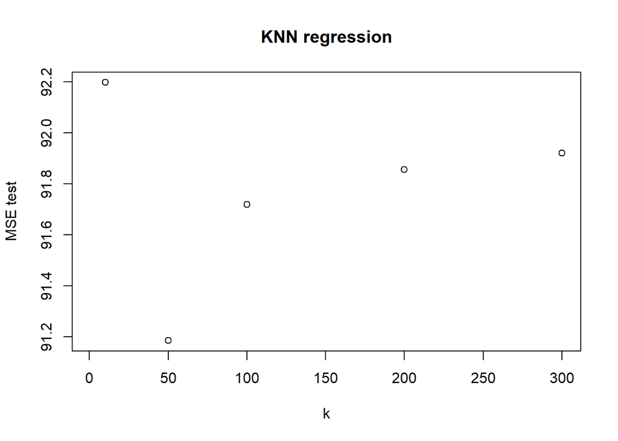

```r
library(caret)
knn_mse_test = NULL

for (k in c(10, 50, 100, 200, 300)){
  kmod <- knnreg(Rings ~ Length, data = abaloneTrain, k = k)
  yhat = predict(kmod, abaloneTest)
  knn_mse_test[k] = mean((abaloneTest$Length - yhat)^2)
}

plot(knn_mse_test, type = "b", ylab = "MSE test", xlab = "k", main = "KNN regression")
```

### Exercise 24

Now we know, visually, that the optimal model lies somewhere around **k = 50** where it has a balance between variance and bias.

### Exercise 25

The model is **over-fitting** the data at **k = 10**. Because when **k** is low, the model is highly sensitive to the training data. It basically memorizes the training examples, capturing the noise in the data and the pattern as well. This results in high variance, where the model performs well on the training data but very poorly on new unseen data, leading to a high test MSE.

### Exercise 26

Based on the observed MSE values, I would pick **k = 50,** where the model is at its most optimal state and provides the best bias-variance trade off because it has the lowest MSE test value.